# ANALISI GEOSTATISTICA DEI DATI AMBIENTALI – Livello base (T28_25_3_1)

# Esercizio SK, OK, UK

Riassumendo; provate a cambiare alcuni parametri e visualizzare il risultato

```r
mean(log(meuse$zinc))
```

```
## [1] 5.885776
```

```r
lz.sk <- krige(log(zinc) ~ 1, meuse, meuse.grid, v.fit, beta = 5.9)
```

```
## [using simple kriging]
```

```r
# spplot(lz.sk)
lz.ok <- krige(log(zinc) ~ 1, meuse, meuse.grid, v.fit)
```

```
## [using ordinary kriging]
```

```r
# spplot(lz.ok)

f <- log(zinc) ~ sqrt(dist)
vt <- variogram(f, meuse)
vt.fit <- fit.variogram(vt, vgm(1, "Exp", 300, 1))

lz.uk <- krige(log(zinc) ~ sqrt(dist), meuse, meuse.grid,  vt.fit)
```

```
## [using universal kriging]
```

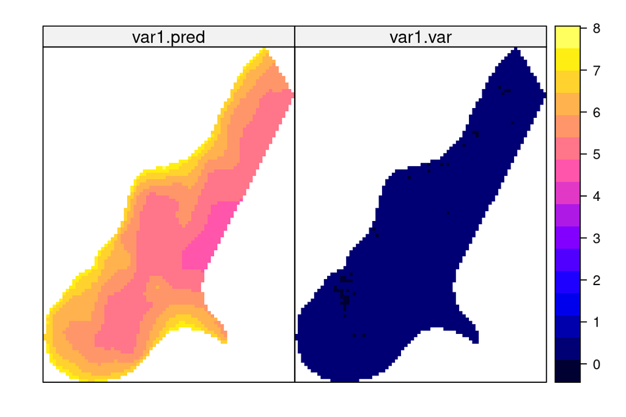

```r
spplot(lz.uk)
```

# Co-Kriging (CK)

Il **Co-kriging** è un’estensione del kriging ordinario che incorpora variabili aggiuntive, note come variabili secondarie o ausiliarie, per migliorare l’accuratezza della previsione della variabile primaria di interesse.

```r
# Creo oggetto gstat con due variabili
g <- gstat(NULL, "zinc", log(zinc)~1, meuse)
g <- gstat(g, "cadmium", log(cadmium)~1, meuse)

# Variogrammi e cross-variogramma
vg <- variogram(g)

# Fit LMC con un modello sferico (va adattato manualmente)
model <- vgm(psill=1, model="Sph", range=900, nugget=0.05)
fit <- fit.lmc(vg, g, model)
```

# Come funziona CK:

- **Variabili multiple:** Considera più variabili contemporaneamente. **Correlazione incrociata:** Utilizza la correlazione incrociata tra le variabili primarie e secondarie.
- Previsione migliorata: Incorporando le informazioni provenienti da variabili correlate, il co-kriging può spesso fornire previsioni più accurate rispetto al kriging ordinario.

# Differenze chiave rispetto al Kriging ordinario:

**Dati:** Il kriging ordinario utilizza una sola variabile, mentre il co-kriging utilizza più variabili.

**Complessità del modello:** Il co-kriging comporta la modellazione delle correlazioni incrociate tra le variabili, rendendolo più complesso del kriging ordinario.

**Accuratezza della previsione:** Il co-kriging spesso porta a un miglioramento dell’accuratezza della previsione grazie alle informazioni aggiuntive fornite dalle variabili secondarie.

# Vantaggi del Co-Kriging:

- **Miglioramento dell’accuratezza:** Come già detto, può migliorare significativamente l’accuratezza della previsione.
- **Uso efficiente dei dati:** Sfrutta le informazioni provenienti da più variabili, sfruttando al massimo i dati disponibili.
- Gestire i dati mancanti: può essere utilizzato per stimare i valori mancanti in una variabile sulla base dei valori di altre variabili.

# Applicazioni del Co-Kriging:

- **Scienze ambientali:** Previsione delle proprietà del suolo, dei livelli di inquinamento atmosferico, ecc. **Idrologia:** Stima dei livelli delle acque sotterranee, delle precipitazioni, ecc. **Geostatistica:** Previsione dei gradi dei minerali, delle riserve minerarie, ecc.

**In sostanza, il co-kriging è uno strumento prezioso quando si hanno più variabili correlate e si vuole migliorare l’accuratezza delle proprie previsioni.**

# External drift Kriging (EDK)

**L’EDK (External Drift Kriging)** è una variante dell’Universal Kriging in cui la componente di tendenza o deriva è determinata da variabili esterne anziché dalle sole coordinate spaziali.

```r
edk <- krige(log(zinc)~dist, meuse, meuse.grid, model=fit)
```

# Come funziona EDK:

- **Variabili esterne:** si tratta di variabili ausiliarie che influenzano la variabile dipendente. Possono essere qualsiasi cosa, dall’altitudine all’uso del suolo, dal tipo di terreno a qualsiasi altro fattore rilevante.
- Un modello di regressione viene utilizzato per modellare la relazione tra la variabile dipendente e le variabili esterne.
- I residui di questo modello di regressione rappresentano la componente spazialmente correlata dei dati. **Kriging:** Il Kriging ordinario viene quindi applicato a questi residui per interpolarli.
- La previsione finale in una località non campionata è la somma del valore previsto dal modello di regressione e del residuo previsto dal kriging.

# Differenze chiave rispetto al Kriging universale:

- **Definizione della deriva:** Il kriging universale utilizza funzioni polinomiali delle coordinate spaziali per modellare la deriva, mentre l’EDK utilizza variabili esterne.
- **Flessibilità:** EDK offre una maggiore flessibilità in quanto può incorporare vari tipi di variabili esterne, migliorando potenzialmente l’accuratezza della previsione.

# Vantaggi dell’EDK:

- **Migliore accuratezza:** Incorporando variabili esterne rilevanti, EDK può spesso fornire previsioni più accurate rispetto a Universal Kriging.
- **Migliore comprensione:** L’EDK aiuta a comprendere l’influenza dei fattori esterni sulla variabile di interesse.
- **Versatilità:** Può essere applicato a un’ampia gamma di dati e problemi spaziali.

**In sostanza, l’External Drift Kriging è un potente strumento di previsione spaziale quando esiste una chiara relazione tra la variabile di interesse e altri fattori esterni.**

# Regression Kriging (RK)

Il **Regression Kriging** è una tecnica di interpolazione spaziale che combina i punti di forza della regressione e del kriging. È essenzialmente un metodo ibrido.

```r
lm_fit <- lm(log(zinc)~dist, data=meuse@data)
meuse$resid <- residuals(lm_fit)

vg_res <- variogram(resid~1, meuse)
fit_res <- fit.variogram(vg_res, vgm("Sph"))

rk <- krige(resid~1, meuse, meuse.grid, model=fit_res)
rk$pred <- rk$var1.pred + predict(lm_fit, meuse.grid@data)
```

# Come funziona RK:

1. Un modello di regressione viene costruito per spiegare la variazione della variabile target utilizzando variabili ausiliarie (covariate).
2. I residui del modello di regressione rappresentano la parte non spiegata della variazione.
3. I residui vengono interpolati con tecniche di kriging (come il Kriging ordinario) per catturare l’autocorrelazione spaziale.
4. La previsione finale è la somma del valore previsto dal modello di regressione e del residuo previsto dal kriging.

# Differenze chiave RK rispetto ad altri metodi:

- **Combina regressione e kriging:** Questo approccio ibrido sfrutta i punti di forza di entrambi i metodi.
- **Incorpora variabili ausiliarie:** Il kriging di regressione utilizza esplicitamente variabili ausiliarie per migliorare l’accuratezza della previsione.
- Il modello di regressione cattura le tendenze su larga scala, mentre il kriging gestisce l’autocorrelazione spaziale su piccola scala.

# Vantaggi di RK:

- **Migliore accuratezza:** Spesso fornisce previsioni più accurate rispetto al semplice kriging o alla sola regressione.
- **Flessibilità:** Può adattarsi a vari tipi di modelli di regressione e tecniche di kriging.
- Migliore comprensione:** Aiuta a capire l’influenza delle variabili ausiliarie sulla variabile target.

# Applicazioni del RK:

- **Scienze ambientali:** Previsione dell’inquinamento atmosferico, delle proprietà del suolo, ecc.
- **Idrologia:** Stima dei livelli delle acque sotterranee, delle precipitazioni, ecc. **Agricoltura:** Previsione della resa dei raccolti, dell’umidità del suolo, ecc.

**In sostanza, il Kriging di regressione è uno strumento potente quando esistono tendenze o modelli significativi nei dati che possono essere spiegati da variabili ausiliarie e quando esiste anche un’autocorrelazione spaziale nei residui.**

# Indicator Kriging (IK)

Tratta i dati come categorici (ad esempio, sopra o sotto una soglia). Utilizzato per la mappatura probabilistica e la valutazione del rischio.

```r
meuse$ind <- ifelse(meuse$zinc > 1000, 1, 0)

vg_ind <- variogram(ind~1, meuse)
fit_ind <- fit.variogram(vg_ind, vgm("Sph"))

ik <- krige(ind~1, meuse, meuse.grid, model=fit_ind)

## oppure (da bivand et al. )
# Definizione della formula indicatore
ind.f <- I(zinc < 500) ~ 1
# Stima del variogramma
ind.fit <- fit.variogram(variogram(ind.f, meuse), vgm(1, "Sph", 800, 1))
# Kriging per indicatori
ind.kr <- krige(ind.f, meuse, meuse.grid, model = ind.fit)
```

# Alcune criticità

I risultati possono risultare carenti quando:

- La geostatistica viene spesso applicata con pochi dati a disposizione.
- Raramente viene indicato il modello di stima e di interpolazione utilizzato.
- Spesso non vengono indicati i punti utilizzati per l’interpolazione e/o i valori che la variabile assume in tali punti, né il dominio di studio.
- A volte vengono utilizzate condizioni al contorno nell’area (punti fittizi) che non rispecchiano dati reali misurati.
- Raramente vengono applicati più modelli di stima allo stesso set di dati ed effettuato il confronto fra le varianze di stima.
- Quando vengono utilizzati modelli statistici (kriging), non viene riportata la determinazione del variogramma sperimentale e del variogramma modello utilizzato, né viene prodotta la mappa delle incertezze.

**non limitarsi solo a fornire delle “mappe”, ma indicare tutte le valutazioni che le hanno prodotte oltre all’incertezza dei risultati.**

# Esercizio finale

Esegui un’interpolazione con IDW (già fatta nel giorno 1 vedi Esercizio finale giorno 1) ed una usando il kriging UK usando sqrt(dist) come covariata - consegnare il raster usando TERRA per salvare come raster GeoTIFF, includendo il sistema di riferimento corretto (vedi Esportiamo raster GeoTIFF per GIS ), come Esercizio finale giorno 1

# Prossimo corso…

- applicazioni dei vari kriging su dataset differente e più complessi
- co-variogrammi e co-kriging per appaiare più covariate
- metodi di validazioni rigorose
- …